# Notebook for event file creation

Joern Alexander Quent

Analysis date: 2025-08-09

# General notes

At the moment, this script only supports data where all trials are completed.

# Libraries used

```r
# Install via devtools:install_github("JAQuent/assortedRFunctions", upgrade = "never")
library(assortedRFunctions)
library(plyr)
library(ggplot2)
library(stringr)
library(cowplot)
library(foreach)
library(doParallel)
```

# Data preparation

**Click here for code for data preparation.**

```r
# Path 2 where the data is saved
path2data        <- "data/ignore_fMRI_version1/"
lookupTable      <- read.csv(paste0(path2data, "lookUpTable.csv"))
```

```r
# Current task folder
taskFolder <- paste0(path2data, "OLM_grassy/")

# Load the subject IDs for this analysis
subjIDs    <- list.files(taskFolder)

# Now check which of these already completed the 7T scan
completed7T <- c()
for(i in 1:length(subjIDs)){
  completed7T[i] <- any(list.files(paste0(taskFolder, subjIDs[i])) == "S007")
}

# Subset to those who completed
subjIDs <- subjIDs[completed7T]

# Create list of all files and load them
allFiles   <- paste0(taskFolder, subjIDs, '/S007/trial_results.csv')
trial_results <- do.call(rbind, lapply(allFiles, read.csv, quote = ""))

# Remove rows with NA values
#trial_results <- na.omit(trial_results)
trial_results <- trial_results[!is.na(trial_results$runStartTime),]

# Relabel ppid to subject to be compatible
trial_results$subject <- trial_results$ppid

# Only retrieval
trial_results_retrieval <- trial_results[trial_results$trialType == "retrieval", ]

# Get cue times
cues_agg <- data.frame(ppid = trial_results$ppid,
                       trial = trial_results$trial_num,
                       start = trial_results$start_time,
                       end = trial_results$start_time + trial_results$cue,
                       duration = trial_results$cue,
                       runStartTime = trial_results$runStartTime,
                       block_num = trial_results$block_num)
# Get delay times
delays_agg <- data.frame(ppid = trial_results$ppid,
                         trial = trial_results$trial_num,
                         start = trial_results$start_time + trial_results$cue,
                         end = trial_results$start_time + trial_results$cue + trial_results$delay,
                         duration = trial_results$delay,
                         runStartTime = trial_results$runStartTime,
                         block_num = trial_results$block_num)
```

```r
# Current task folder
taskFolder <- paste0(path2data, "OLM_grassy/")

# Load the subject IDs for this analysis
subjIDs    <- list.files(taskFolder)

# Now check which of these already completed the 7T scan
completed7T <- c()
for(i in 1:length(subjIDs)){
  completed7T[i] <- any(list.files(paste0(taskFolder, subjIDs[i])) == "S007")
}

# Subset to those who completed
subjIDs <- subjIDs[completed7T]
```

## Folder & file naming convention

**Code to create file & folder names**

```r
# String parts
task <- "OLM"

# Other information
folder    <- "event_tables/"
session   <- "S007"
runs      <- c(1, 1, 2, 2) # OlMe run1, OLMr run 1, OLMe run 2 etc.
runType   <- c("e", "r", "e", "r")

# Create folders for this subject and for the session
ses <- 1 #as.numeric(gsub("[^0-9.-]", "", session))

# Memory encoding
OLMe_7T_encoding_folder1 <- paste0(folder, 'OLMe_7T_encoding1/', "sub-", subjIDs, "/ses-", sprintf("%02d", ses), "/")
for(subj in 1:length(subjIDs)){
  dir.create(OLMe_7T_encoding_folder1[subj], recursive = TRUE, showWarnings = FALSE)
}
```

# Memory encoding

Traditional studies of memory often back sort items as a function of whether the memoranda were remembered or forgotten. This not straightforward in our task, however what we can do is to rank the objects based on the average placement error for each subject and then model encoding success as ordered regressors for the 1st, 2nd etc. object.

Cope 1 = Rank 1: Smallest placement error … Cope 6 = Rank 6: Highest placement error

Cope 7 + the linear contrast with Rank 1 > … > Rank 6

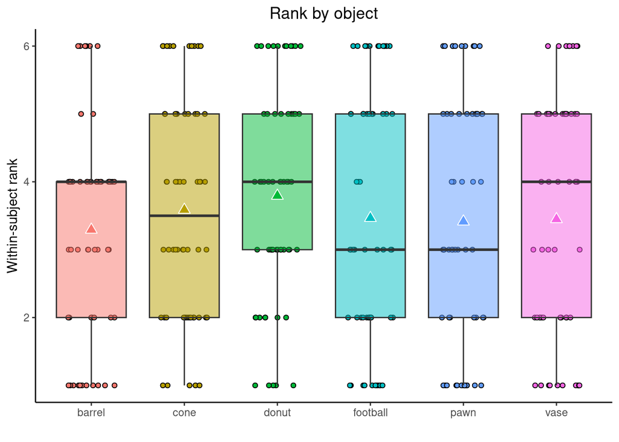

```r
# Calculate the average placement error for each object & subject.
obj_avg <- ddply(trial_results_retrieval, c("subject", "objectName"), summarise,
                 euclideanDistance = mean(euclideanDistance), N = length(subject))

# Rank the objects within each subject
obj_avg <- ddply(obj_avg, c("subject"), mutate, rank = order(euclideanDistance))
obj_avg$f_rank <- factor(obj_avg$rank)

# Visualise results
ggplot(obj_avg, aes(x = objectName, y = rank, fill = objectName)) +
  geom_jitter(width = 0.25, height = 0, pch = 21) +
  geom_boxplot(outlier.shape = NA, alpha = 0.5) +
  stat_summary(geom = "point", fun = "mean", col = 'white', size = 3, shape = 24, aes(fill = objectName),
               position = position_dodge(width =  0.75),
               key_glyph = "rect") +
  labs(title = "Rank by object",
       x = "", y = "Within-subject rank")  +
  theme_classic() +
  theme(legend.position = 'none',
        plot.title = element_text(hjust = 0.5))
```

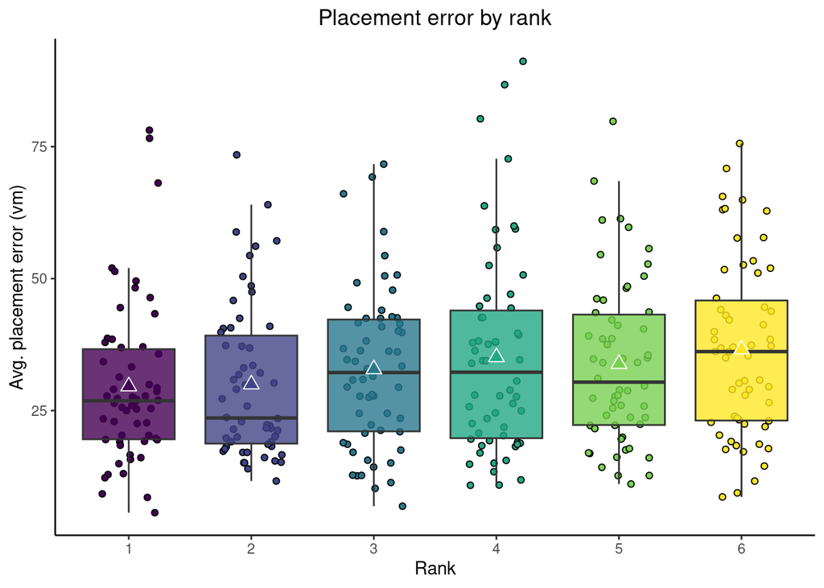

```r
ggplot(obj_avg, aes(x = f_rank, y = euclideanDistance, fill = f_rank)) +
  geom_jitter(width = 0.25, height = 0, pch = 21) +
  geom_boxplot(outlier.shape = NA, alpha = 0.8) +
  stat_summary(geom = "point", fun = "mean", col = 'white', size = 3, shape = 24, aes(fill = f_rank),
               position = position_dodge(width =  0.75),
               key_glyph = "rect") +
  labs(title = "Placement error by rank",
       x = "Rank", y = "Avg. placement error (vm)")  +
  theme_classic() +
  scale_fill_viridis_d() +
  theme(legend.position = 'none',
        plot.title = element_text(hjust = 0.5))
```

The ranking of the objects looks relative uniform so there should be no problem sorting each encoding trial based on the this rank. Regressor will model the whole trial apart from the cue & delay period. The nice thing about this model is that each participant (regardless of their average performance) will have the same number of events (3 trials per run) in all conditions. Rank 1 to 6 will be modelled via this contrast: 2.5, 1.5, 0.5, -0.5, -1.5, -2.5

```r
# Specify runs
runs_encoding  <- c(1, 2) # OlMe run1, OLMe run 2

# Loop through all subjects
for(subj in 1:length(subjIDs)){
  # The easiest way to create the condition labels for fMRI analysis seems to be to loop
  # through each trial and then create and event for each step.
  # Create empty DF where new events will be added to.
  encodingEvents <- data.frame(matrix(ncol = 6, nrow = 0))

  # Change the column names so new rows can be added using rbind()
  colnames(encodingEvents) <- c('block_num', 'eventType', 'onset', 'duration', 'weight', "runStartTime")

  # Get the encoding data from only the current subject
  sub_main_results <- trial_results[trial_results$subject == subjIDs[subj] &
                                      trial_results$trialType == "encoding", ]

  # Loop through each row of the sub_main_results data frame and create the events for the
  # memory analysis one by one.
  for(rowID in 1:nrow(sub_main_results)){
    # Check which rank the current object is for the current subject
    currentSubject <- sub_main_results$subject[rowID]
    currentObject  <- sub_main_results$objectName[rowID]
    currentRank    <- obj_avg[obj_avg$subject == currentSubject &
                              obj_avg$objectName == currentObject, 'rank']

    # Add event for this row from navigation start until the end of the trial
    duration <- sub_main_results$end_time[rowID] - sub_main_results$navStartTime[rowID]
    encodingEvents <- rbind(encodingEvents, data.frame(block_num = sub_main_results$block_num[rowID],
                                       eventType = currentRank,
                                       onset = sub_main_results$navStartTime[rowID],
                                       duration = duration,
                                       weight = 1,
                                       runStartTime = sub_main_results$runStartTime[rowID]))

  }

  # Using the created encodingEvents data frame to generate event tables
  for(run in 1:length_uniq(encodingEvents$block_num)){
    tempDF <- encodingEvents[encodingEvents$block_num == unique(encodingEvents$block_num)[run], ]
    block_num           <- unique(tempDF$block_num)
    tempDF$block_num    <- NULL
    tempDF$onset        <- tempDF$onset - tempDF$runStartTime[1]
    tempDF$runStartTime <- NULL

    # One-file-per-condition style
    # Create the following folder structure sub-R0132>ses-07>run-01>EVs>cue_retrieval.txt
    # cue_retrieval.txt would have the following columns onset, duration & weight (always 1) separated by tab.
    # Create folder for this run
    currentFolder <- paste0(OLMe_7T_encoding_folder1[subj], "run-", sprintf("%02d", runs_encoding[run]), "/EVs/")
    dir.create(currentFolder, recursive = TRUE, showWarnings = FALSE)

    # Look for different event types
    tempEventType  <- unique(tempDF$eventType)
    numEventsTypes <- length(tempEventType)
    # Loop through all unique event types
    # cue_retrieval.txt would have the following columns onset, duration & weight (always 1) separated by tab.
    for(event in 1:numEventsTypes){
      # Get the subset of exactly that event type
      tempDF2 <- tempDF[tempDF$eventType == tempEventType[event],]

      # Remove first column
      tempDF2$eventType <- NULL

      # Write to .txt file
      fileName <- paste0("rank_", tempEventType[event], ".txt")
      fileName <- str_replace_all(fileName, " ", "_") # Remove the space to make things easier in unix.
      write.table(tempDF2,
                file = paste0(currentFolder, fileName),
                col.names = FALSE,
                row.names = FALSE,
                quote =  FALSE,
                sep = '\t')
    }

    # Write event files for cue and delay
    ## Cue
    cue_sub <- cues_agg[cues_agg$ppid == subjIDs[subj] & cues_agg$block_num == block_num, ]
    tempDF  <- data.frame(onset = cue_sub$start - cue_sub$runStartTime,
                         duration = cue_sub$duration, weight = 1)
    write.table(tempDF,
                file = paste0(currentFolder, "cue.txt"),
                col.names = FALSE, row.names = FALSE, quote =  FALSE, sep = '\t')

    ## Delay
    delay_sub <- delays_agg[delays_agg$ppid == subjIDs[subj] & delays_agg$block_num == block_num, ]
    tempDF    <- data.frame(onset = delay_sub$start - delay_sub$runStartTime,
                         duration = delay_sub$duration, weight = 1)
    write.table(tempDF,
                file = paste0(currentFolder, "delay.txt"),
                col.names = FALSE, row.names = FALSE, quote =  FALSE, sep = '\t')
  }
}
```